# Video analysis for urchin deterrence experiment

Amelia Ritger

10/11/2019

### Load packages, load data, tidy data

##### *magic happening behind the scenes*

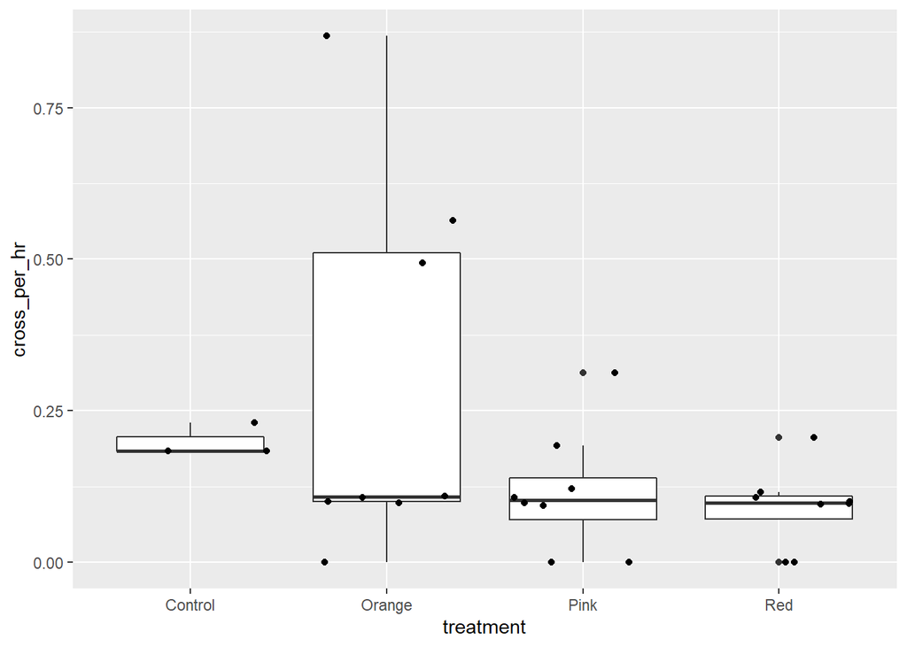

### Some prelimiary analysis: plotting some possibly correlated variables

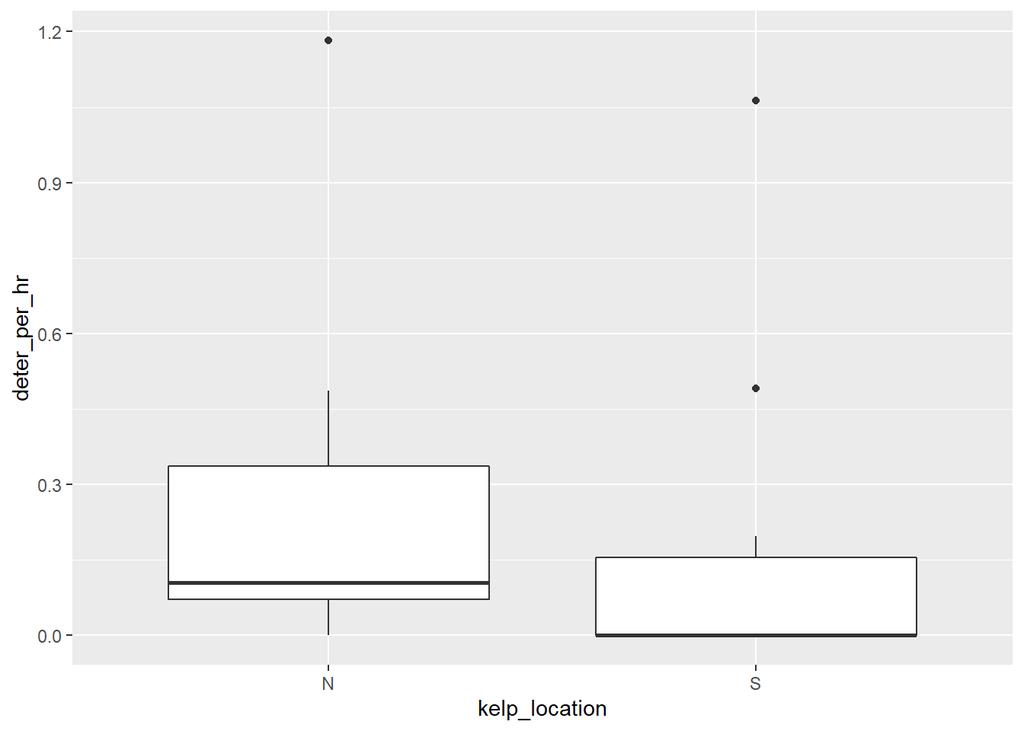

No correlation between where kelp was placed in tank and deterrences per hour

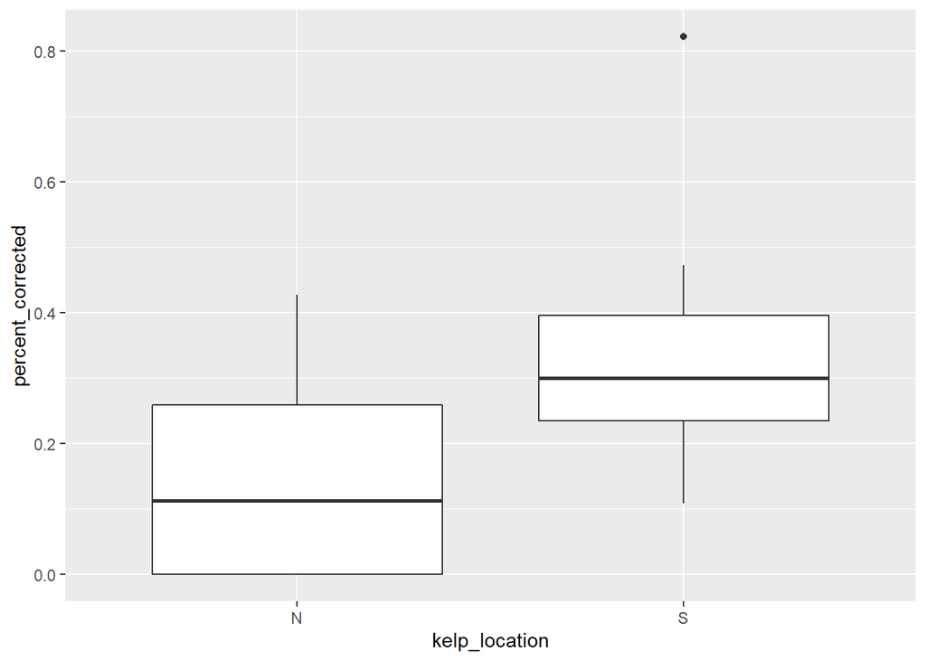

No correlation between where kelp was placed in tank and percent of kelp consumed

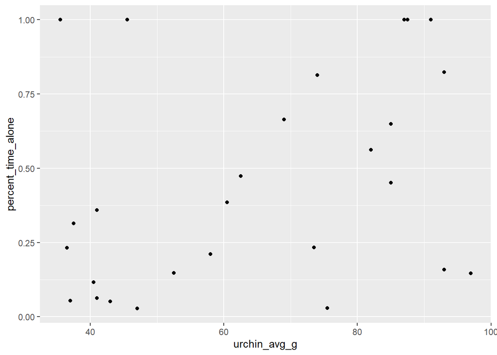

No real correlation between urchin size and percent of time urchin spent alone during trial

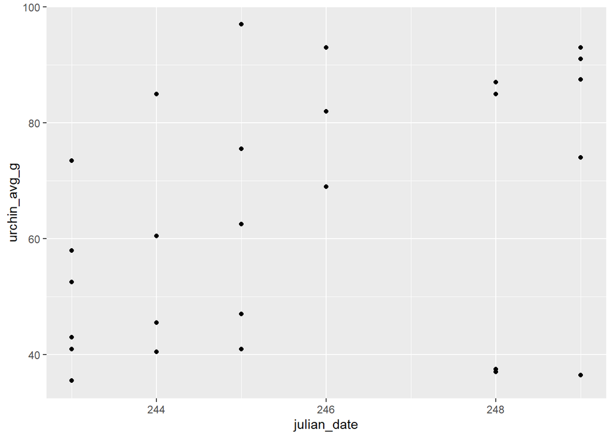

As expected, urchins were either big or small later on in experiment as I ran out of urchins

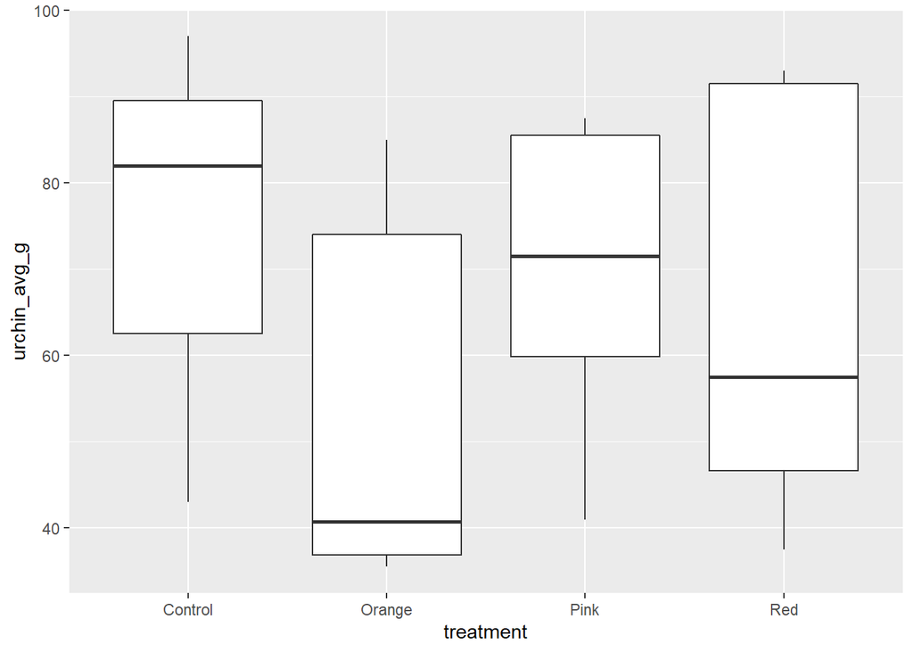

No real correlation between treatment and urchin size used

### Is there any correlation with amount of kelp consumed and urchin size?

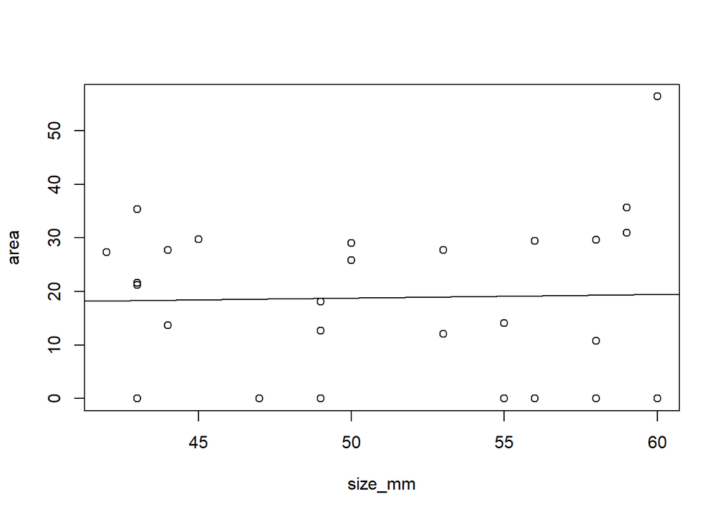

Urchin size had no correlation with amount of kelp consumed

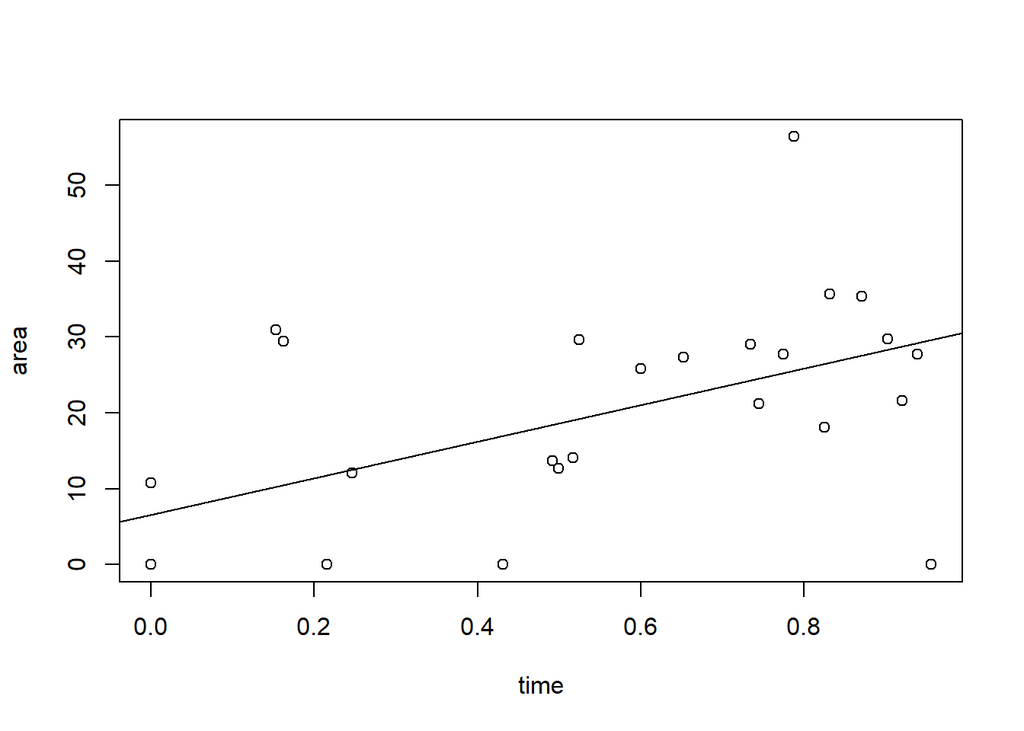

But the more time spent with kelp >> more kelp consumed (no surprise)

How might these variables interact with kelp consumption?

```
##
## Call:
## lm(formula = area ~ time + size + (time:size))
##
## Residuals:
##      Min       1Q   Median       3Q      Max
## -26.8148  -6.2659  -0.4257   4.5458  19.3747
##
## Coefficients:
##             Estimate Std. Error t value Pr(>|t|)
## (Intercept)  -1.0410    14.5406  -0.072    0.944
## time         11.3609    21.0356   0.540    0.594
## size          0.0841     0.1947   0.432    0.670
## time:size     0.2906     0.3114   0.933    0.360
##
## Residual standard error: 11.64 on 23 degrees of freedom
## Multiple R-squared:  0.4372, Adjusted R-squared:  0.3638
## F-statistic: 5.955 on 3 and 23 DF,  p-value: 0.00369
```

It doesn’t seem like, statistically, there are any effects or interacting effects on area of kelp consumed

So: larger urchins weren’t eating more kelp, larger urchins weren’t spending more time with kelp, if anything they spent less time with kelp, and (obviously) more time spent with kelp = more kelp consumed

### Is there an effect of urchin size on time to cross tile?

Time to cross tile (Y) has been log transformed to meet assumptions of normality

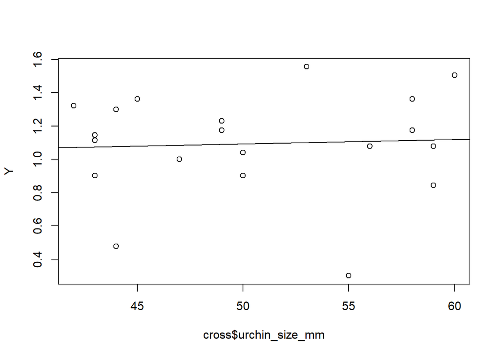

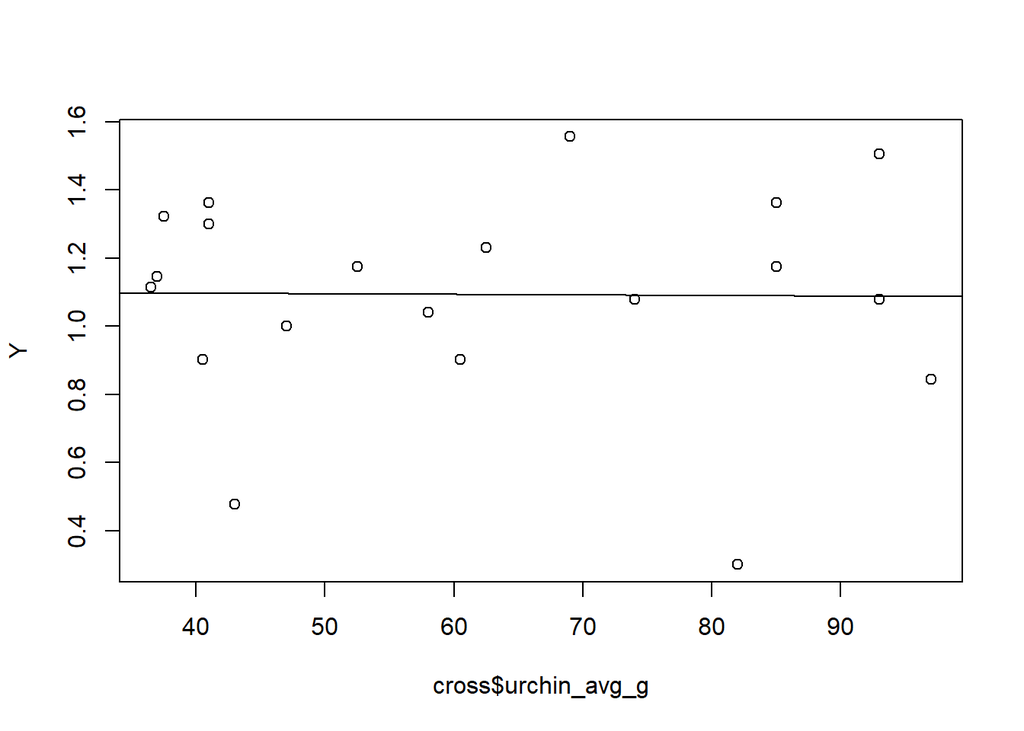

```
##
## Call:
## lm(formula = Y ~ cross$urchin_avg_g)
##
## Residuals:
##      Min       1Q   Median       3Q      Max
## -0.78941 -0.12023  0.03163  0.20852  0.46358
##
## Coefficients:
##                     Estimate Std. Error t value Pr(>|t|)
## (Intercept)         1.104870   0.221593   4.986 9.57e-05 ***
## cross$urchin_avg_g -0.000176   0.003400  -0.052    0.959
## ---
## Signif. codes:  0 '***' 0.001 '**' 0.01 '*' 0.05 '.' 0.1 ' ' 1
##
## Residual standard error: 0.3173 on 18 degrees of freedom
## Multiple R-squared:  0.0001489,  Adjusted R-squared:  -0.0554
## F-statistic: 0.00268 on 1 and 18 DF,  p-value: 0.9593
```

Definitely no effect of urchin size on time it takes them to cross the tile

# Now onto the meat of the analysis

## How does presence of Corynactis affect “outcome”?

#### **Outcome options:**

- Cory was beast = Urchin never crossed over Corynactis tile
- Cory was close = Urchin was deterred from Corynactis tile at least once but ultimately crossed over tile
- Uchin was beast = Urchin was never deterred from Corynactis tile

#### Because data is binary and sample size is small (control n = 3), use N-1 Two Proportion Test or Fisher’s Exact Test

```
##                   X
## outcome            absent present
##   Cory was beast        0       4
##   Cory was close        0      11
##   Urchin was beast      3       9
```

```
##
##  3-sample test for equality of proportions without continuity
##  correction
##
## data:  t1
## X-squared = 4.2188, df = 2, p-value = 0.1213
## alternative hypothesis: two.sided
## sample estimates:
## prop 1 prop 2 prop 3
##   0.00   0.00   0.25
```

```
##
##  Fisher's Exact Test for Count Data
##
## data:  t1
## p-value = 0.2554
## alternative hypothesis: two.sided
```

Urchins always crossed tile when it didn’t have Corynactis, but it wasn’t statistically significant (probably because of low control sample size)

## How does treatment type affect “outcome”?

```
##
##  Pearson's Chi-squared test
##
## data:  t1
## X-squared = 1.8939, df = 4, p-value = 0.7553
```

```
##
##  Fisher's Exact Test for Count Data
##
## data:  t1
## p-value = 0.8155
## alternative hypothesis: two.sided
```

Different color morphs definitely did not result in different outcomes

## How does presence of Corynactis affect whether or not urchin was deterred (regardless of ultimate outcome)?

```
##          deter
## X          0  1
##   absent   3  0
##   present  7 17
```

```
##
##  2-sample test for equality of proportions with continuity
##  correction
##
## data:  t1
## X-squared = 3.102, df = 1, p-value = 0.0782
## alternative hypothesis: two.sided
## 95 percent confidence interval:
##  0.3389869 1.0000000
## sample estimates:
##    prop 1    prop 2
## 1.0000000 0.2916667
```

```
##
##  Fisher's Exact Test for Count Data
##
## data:  t1
## p-value = 0.04103
## alternative hypothesis: true odds ratio is not equal to 1
## 95 percent confidence interval:
##  0.7775348       Inf
## sample estimates:
## odds ratio
##        Inf
```

Urchin was never detered from tile when Corynactis was absent, urchins were likely to be deterred when Corynactis present, but this is not really statistically significant (it depends which test you use)

## How does type of Corynactis affect whether or not urchin was deterred (regardless of ultimate outcome)?

```
##
##  3-sample test for equality of proportions without continuity
##  correction
##
## data:  t1
## X-squared = 0.40336, df = 2, p-value = 0.8174
## alternative hypothesis: two.sided
## sample estimates:
## prop 1 prop 2 prop 3
##  0.375  0.250  0.250
```

```
##
##  Fisher's Exact Test for Count Data
##
## data:  t1
## p-value = 1
## alternative hypothesis: two.sided
```

Treatment type does not affect whether or not an urchin was deterred at least once

## Is there an effect of Corynactis (yes/no) on time to cross tile?

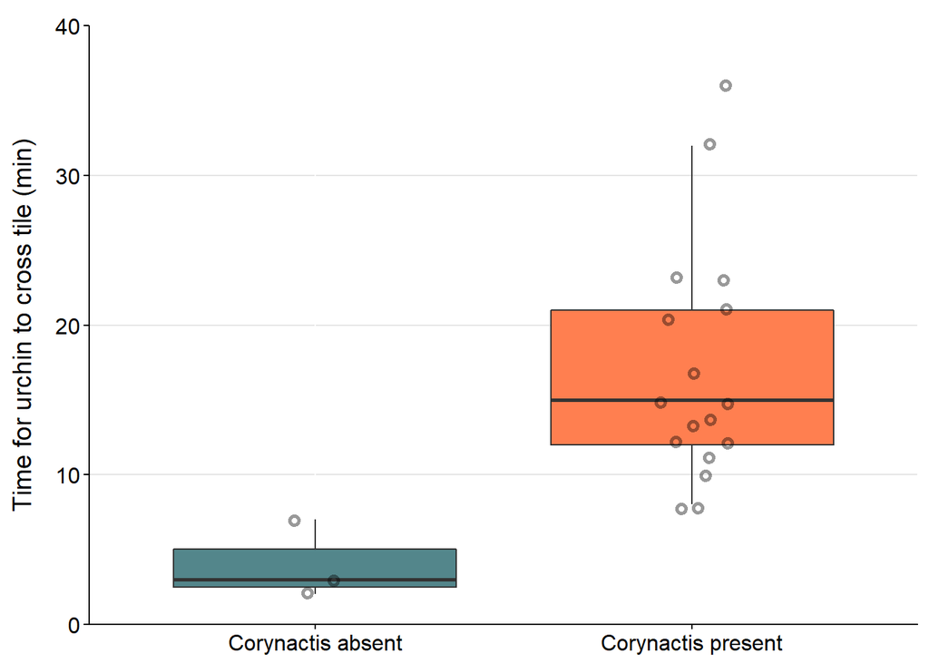

<< This is a potential plot for WSN poster

```
##
##  Welch Two Sample t-test
##
## data:  log10(cross$time_to_cross_cory_first_min) by as.factor(cross$corynactis_binary)
## t = -3.9, df = 2.3434, p-value = 0.0461
## alternative hypothesis: true difference in means is not equal to 0
## 95 percent confidence interval:
##  -1.27622537 -0.02476084
## sample estimates:
##  mean in group absent mean in group present
##             0.5410831             1.1915762
```

When Corynactis were present, the time it took an urchin to cross the tile was significantly longer

## Is there an effect of treatment on time to cross tile?

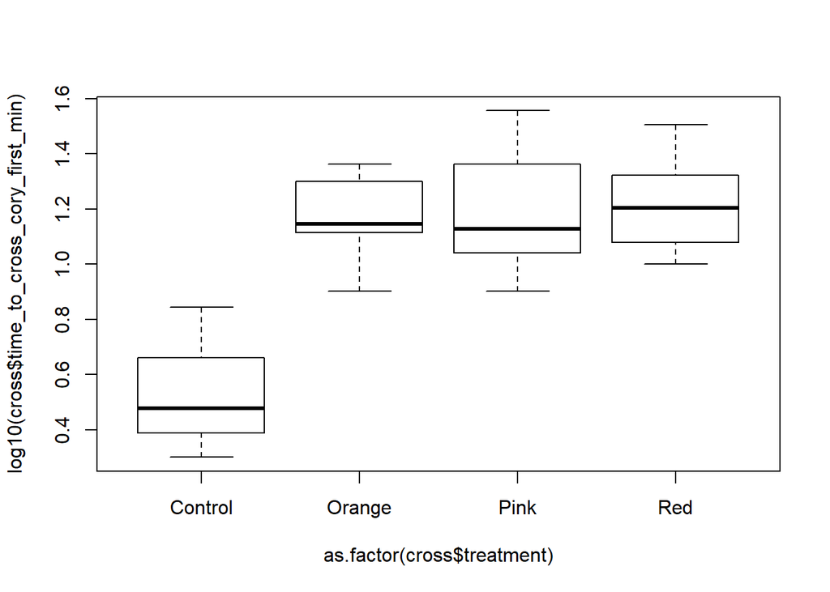

```
##                            Df Sum Sq Mean Sq F value  Pr(>F)
## as.factor(cross$treatment)  3 1.0871  0.3624   7.993 0.00176 **
## Residuals                  16 0.7254  0.0453
## ---
## Signif. codes:  0 '***' 0.001 '**' 0.01 '*' 0.05 '.' 0.1 ' ' 1
```

```
##   Tukey multiple comparisons of means
##     95% family-wise confidence level
##
## Fit: aov(formula = log10(cross$time_to_cross_cory_first_min) ~ as.factor(cross$treatment))
##
## $`as.factor(cross$treatment)`
##                      diff        lwr       upr     p adj
## Orange-Control 0.62410074  0.1792184 1.0689831 0.0049834
## Pink-Control   0.64521449  0.2144590 1.0759700 0.0028663
## Red-Control    0.67776535  0.2470099 1.1085208 0.0018496
## Pink-Orange    0.02111374 -0.3477632 0.3899907 0.9983696
## Red-Orange     0.05366461 -0.3152124 0.4225416 0.9748946
## Red-Pink       0.03255086 -0.3191595 0.3842612 0.9932382
```

All experimental treatments are significantly different from control treatment, but there is no signficant difference amongst color morphs

## Presence of Corynactis: effect on % of contacts that resulted in deterrence?

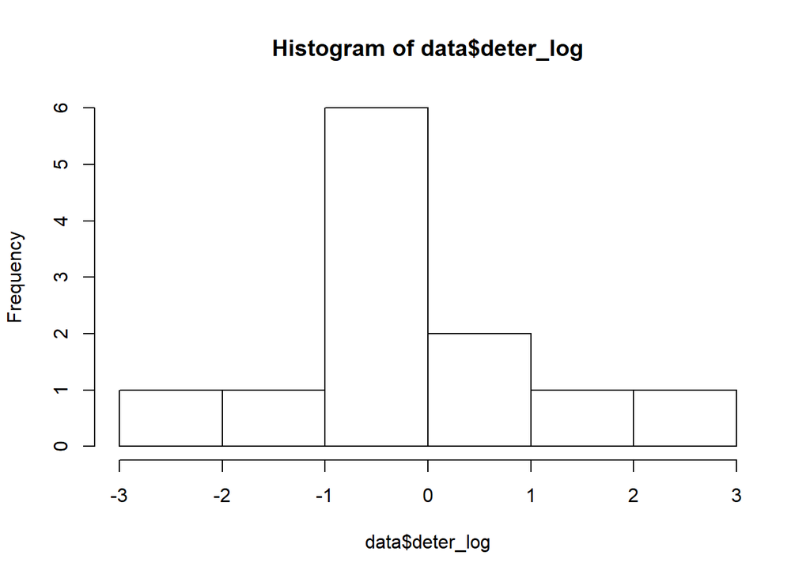

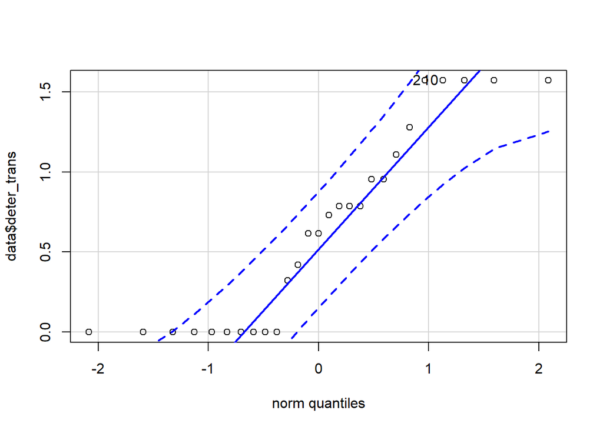

```
## [1]  2 10
```

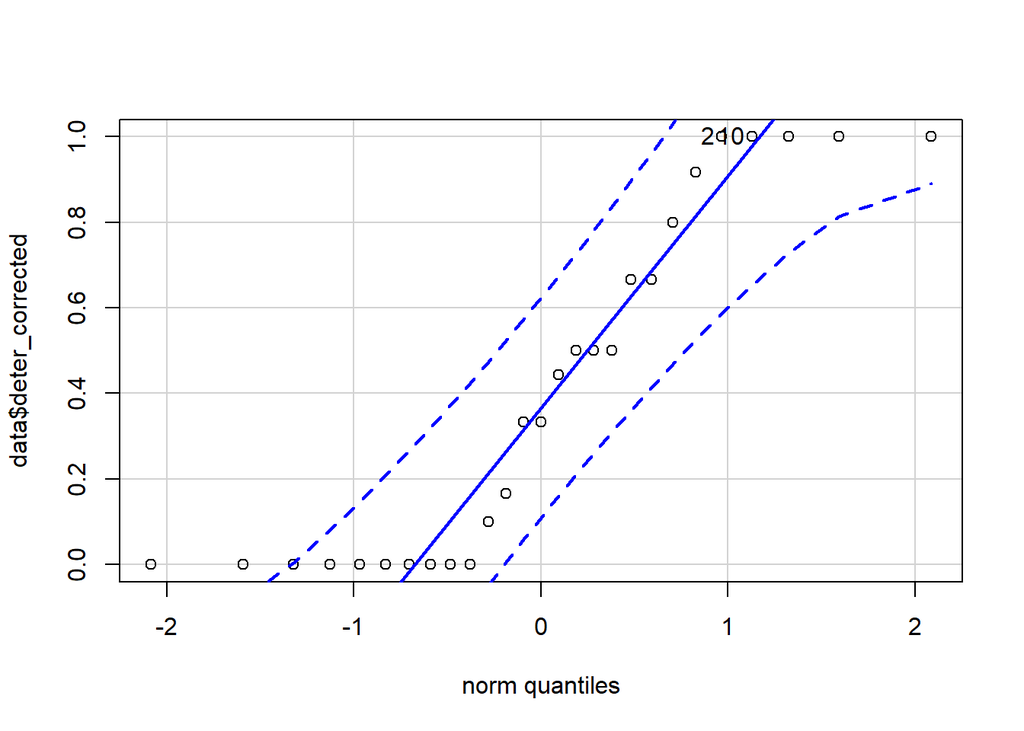

```
## [1]  2 10
```

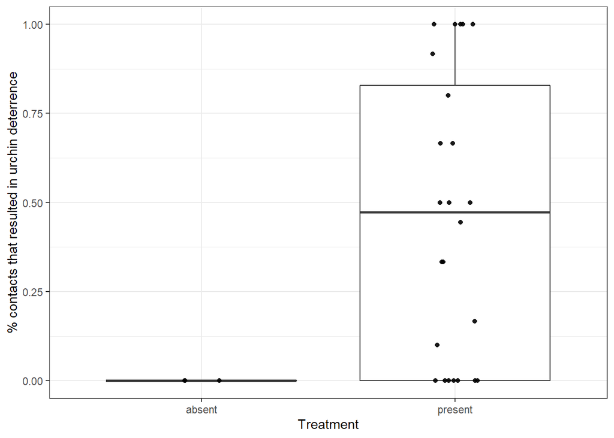

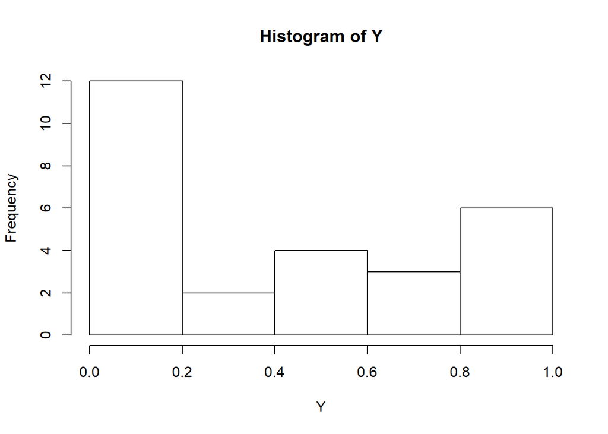

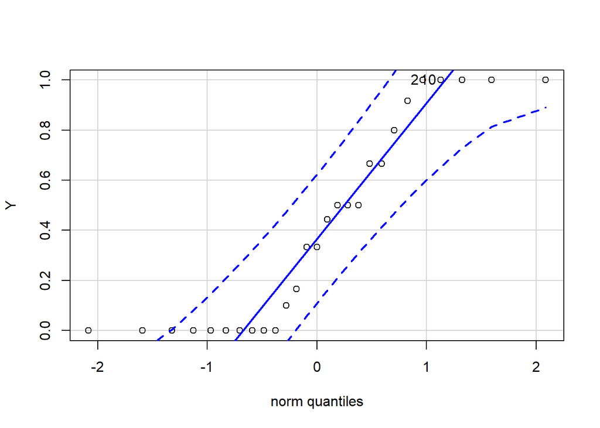

```
## [1]  2 10
```

### There are many zeros that have not been corrected for in the analysis

#### AND this is not really a different question from the “presence affecting outcome” question

## Type of Corynactis: effect on % of contacts that resulted in deterrence?

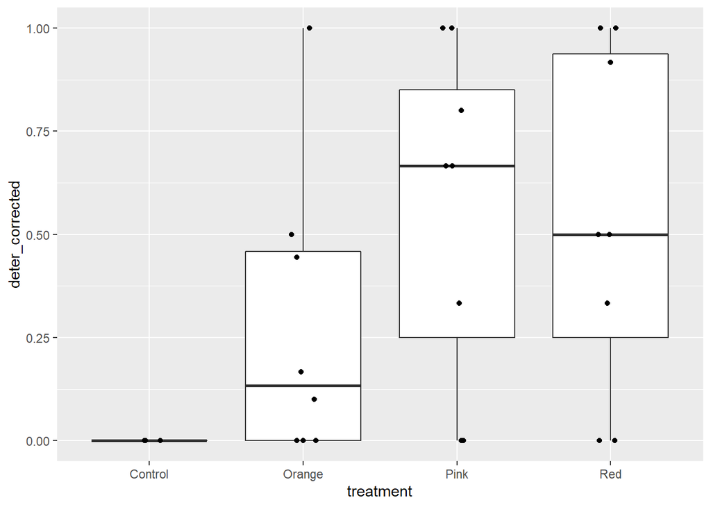

Maybe there is a difference between orange and pink/red?

```
##                 Df Sum Sq Mean Sq F value Pr(>F)
## deter$treatment  3  0.940  0.3133   2.242   0.11
## Residuals       23  3.214  0.1397
```

```
##   Tukey multiple comparisons of means
##     95% family-wise confidence level
##
## Fit: aov(formula = deter$deter_corrected ~ deter$treatment)
##
## $`deter$treatment`
##                       diff        lwr       upr     p adj
## Orange-Control  0.27638889 -0.4239333 0.9767111 0.6977248
## Pink-Control    0.55833333 -0.1419889 1.2586555 0.1513964
## Red-Control     0.53125000 -0.1690722 1.2315722 0.1831840
## Pink-Orange     0.28194444 -0.2352778 0.7991667 0.4488654
## Red-Orange      0.25486111 -0.2623611 0.7720833 0.5337505
## Red-Pink       -0.02708333 -0.5443056 0.4901389 0.9988820
```

No, definitely no difference.

Plot means + confidence intervals of the groups

```r
library(Rmisc)
```

```r
deterred <- summarySE(deter, measurevar="deter_corrected", groupvars="treatment")
mean <- deterred$deter_corrected
ci <- deterred$ci

# ggplot(deter, aes(x=treatment, y=deter_corrected, color=treatment)) +
#   geom_jitter(size=4, alpha=0.5, width=0.1, show.legend=FALSE) +
#   scale_color_manual(values=c("cadetblue4", "orange", "pink", "red")) +
#   geom_segment(data=deterred, aes(x=c(0.5,1.5,2.5,3.5), xend=c(1.5,2.5,3.5,4.5), y=mean, yend=mean), size=3, show.legend=FALSE) +
#   geom_segment(data=deterred, aes(x=c(1,2,3,4), xend=c(1,2,3,4), y=mean+ci, yend=mean-ci), size=1.5, show.legend=FALSE, alpha=0.5) +
#   geom_segment(x=2, xend=2, y=0.2763889+0.2954399, yend=0.2763889-0.2954399, size=2, color="orange", alpha=0.2)+
#   labs(x="Treatment", y="Proportion of contacts resulting in deterrence") +
#   #scale_x_discrete(labels = c('Corynactis absent','Corynactis present')) +
#   scale_y_continuous(limits=c(0,1.05),expand = c(0,0), breaks=c(0,0.2,0.4,0.6,0.8,1)) +
#   coord_flip() +
#   theme(panel.grid.major.x  = element_line(color = "grey90"),
#       panel.background = element_rect(fill = "white"),
#       panel.border = element_rect(color = "white", fill = NA),
#       axis.line = element_line(color = "black"),
#       axis.ticks = element_line(color = "black"),
#       axis.text = element_text(color = "black", size=12),
#       axis.title.y = element_text(vjust=4, size=14),
#       axis.title.x = element_text(size=14, vjust=-1.5),
#       plot.margin=unit(c(0.2,0.2,0.5,0.5), "cm"))
```

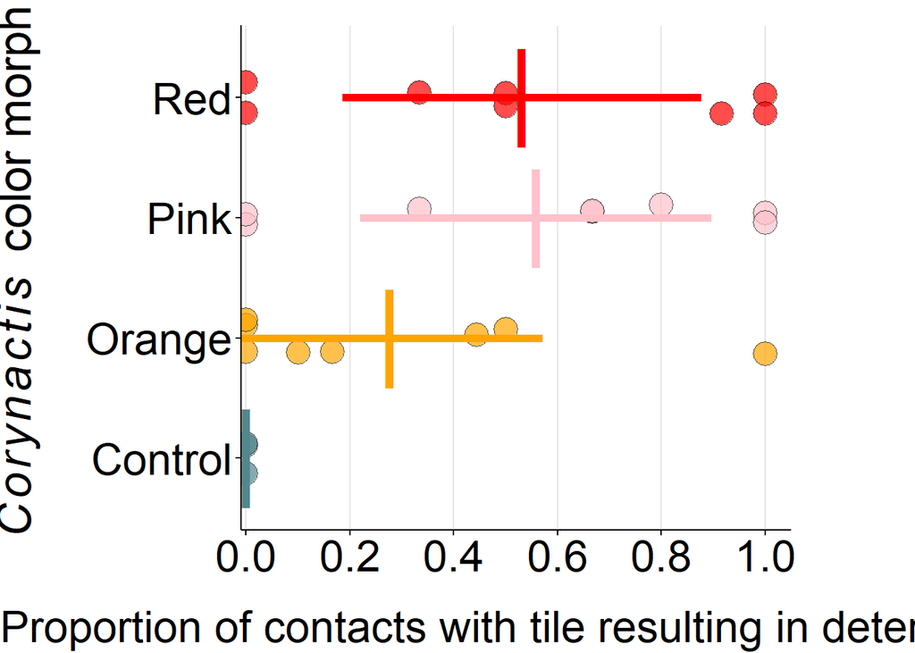

```r
ggplot(deterred, aes(x=treatment, y=deter_corrected, color=treatment)) +
  geom_jitter(data=deter, aes(fill=treatment), pch=21, color="black", size=6, alpha=0.7, width=0.15, show.legend=FALSE) +
  scale_fill_manual(values=c("cadetblue4", "orange", "pink", "red")) +
  geom_point(aes(color=treatment), shape=124, size=20, show.legend=FALSE) +
  geom_segment(aes(y=deter_corrected-ci, x=treatment, yend=deter_corrected+ci, xend=treatment), show.legend=FALSE, size=2) +
  geom_segment(x=2, xend=2, y=0.2763889+0.2954399, yend=0.2763889-0.2954399, color="orange", size=2)+
  scale_color_manual(values=c("cadetblue4", "orange", "pink", "red")) +
  #geom_segment(aes(y=deter_corrected-ci, x=treatment, yend=deter_corrected+ci, xend=treatment), show.legend=FALSE) +
  labs(x=expression(~italic(Corynactis)~' color morph'), y="Proportion of contacts with tile resulting in deterrence") +
  scale_y_continuous(limits=c(-0.01,1.05),expand = c(0,0), breaks=c(0,0.2,0.4,0.6,0.8,1)) +
  coord_flip() +
  theme(panel.grid.major.x  = element_line(color = "grey90"),
      panel.background = element_rect(fill = "white"),
      panel.border = element_rect(color = "white", fill = NA),
      axis.line = element_line(color = "black"),
      axis.ticks = element_line(color = "black"),
      axis.text = element_text(color = "black", size=24),
      axis.title.y = element_text(size=26, vjust=4),
      axis.title.x = element_text(size=24, vjust=-1.5),
      plot.margin=unit(c(0.5,2.4,0.5,0.5), "cm"))
```

```r
ggsave(here::here("figures", "treatment by percent deterrence.png"), width=9, height=6.75)
```

### Treat data like Bernoulli: each contact by urchin can result in either success or failure. Also treat data as a beta distribution with zero and one inflation.

```
##
## Call:
## glm(formula = cbind(success, failure) ~ treatment, family = binomial,
##     data = deter)
##
## Deviance Residuals:
##     Min       1Q   Median       3Q      Max
## -2.8546  -1.1805  -0.2935   0.6358   3.0046
##
## Coefficients:
##                 Estimate Std. Error z value Pr(>|z|)
## (Intercept)       -17.57    2284.10  -0.008    0.994
## treatmentOrange    16.83    2284.10   0.007    0.994
## treatmentPink      18.63    2284.10   0.008    0.993
## treatmentRed       18.62    2284.10   0.008    0.993
##
## (Dispersion parameter for binomial family taken to be 1)
##
##     Null deviance: 75.206  on 26  degrees of freedom
## Residual deviance: 53.857  on 23  degrees of freedom
## AIC: 82.615
##
## Number of Fisher Scoring iterations: 16
```

```
## Family:  c("BEINF", "Beta Inflated")
##
## Call:  gamlss(formula = Y ~ X, family = BEINF, trace = F)
##
## Fitting method: RS()
##
## ------------------------------------------------------------------
## Mu link function:  logit
## Mu Coefficients:
##               Estimate Std. Error t value Pr(>|t|)
## (Intercept)    -1.3716 33554.4656       0        1
## XOrange         0.5497 33554.4655       0        1
## XPink           1.8026 33554.4656       0        1
## XRed            1.7256 33554.4656       0        1
##
## ------------------------------------------------------------------
## Sigma link function:  logit
## Sigma Coefficients:
##             Estimate Std. Error t value Pr(>|t|)
## (Intercept)  -0.4526     0.2641  -1.714    0.102
##
## ------------------------------------------------------------------
## Nu link function:  log
## Nu Coefficients:
##             Estimate Std. Error t value Pr(>|t|)
## (Intercept)  -0.1838     0.4282  -0.429    0.672
##
## ------------------------------------------------------------------
## Tau link function:  log
## Tau Coefficients:
##             Estimate Std. Error t value Pr(>|t|)
## (Intercept)  -0.8761     0.5322  -1.646    0.115
##
## ------------------------------------------------------------------
## No. of observations in the fit:  27
## Degrees of Freedom for the fit:  7
##       Residual Deg. of Freedom:  20
##                       at cycle:  3
##
## Global Deviance:     48.76305
##             AIC:     62.76305
##             SBC:     71.83391
```

###### Interpretation:

###### - Mu represents the mean of the beta distribution part of the model for the interval (0,1)

###### - Sigma represents the precision (or shape) of the beta distribution part of the model

###### - Nu represents the Bernoulli distribution part of the model and probability of observing zeros

Nope, there is no significant difference between treatments and % of contacts that resulted in deterrence

# So, in conclusion:

#### There was no significant difference between color morphs affecting the “outcome”

#### Corynactis caused urchins to take longer to cross the tile (but there was no effect of color morph)

#### Larger urchins did not spend more time with kelp or eat more kelp

#### Larger urchins did not cross the Corynactis tile more quickly (or slowly) than smaller urchins

### AKA: Corynactis had an effect on urchin behavior as we measured it with GoPros, but there wasn’t necessarily a difference between color morphs on urchin behavior